# Home

- Blog
- Contact
- About
- Current Projects
- CV
- MA376 Course Notes

# Class Test

Published Tue, Jul 23, 2019 by [Nicholas Clark](https://google.com/+XXX)

Estimated reading time: 19 min

# Class Test

Nicholas Clark

2019-07-23T21:13:14-05:00

# Contact Information

LTC Nick Clark

nicholas.clark@westpoint.edu

Thayer Hall Room 249

845-938-7461

# Course Overview

Statistics

-Learn Statistics by doing

-Hands on/interactive

-R/Rstudio

-Course Overview

-Graded Events

#Introductions

#Berkely Admissions Data

In the early 1970s, the University of California at Berkeley was concerned with possible discrimination against women in its graduate admissions process. Data about the applicants for the 1972–73 school year were recorded from several programs, including their sex and whether or not they were accepted (Bickel & O’Connell, Science, 1975).

```r
#install.packages("tidyverse")
library(tidyverse)
berkley.data<-read.table("http://www.isi-stats.com/isi2/data/Berkeley.txt",header=T)
```

Observational Unit:

Response Variable:

Values Response Variable can take on:

Visualize

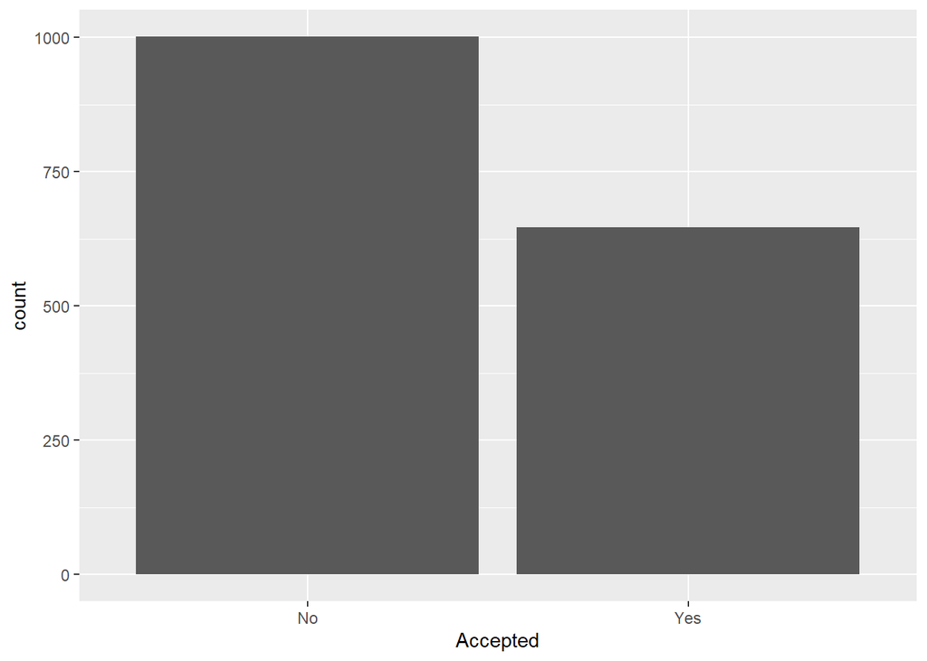

```r
ggplot(data=berkley.data,aes(Accepted))+geom_histogram(stat="count")
```

Explore

Visualize the table:

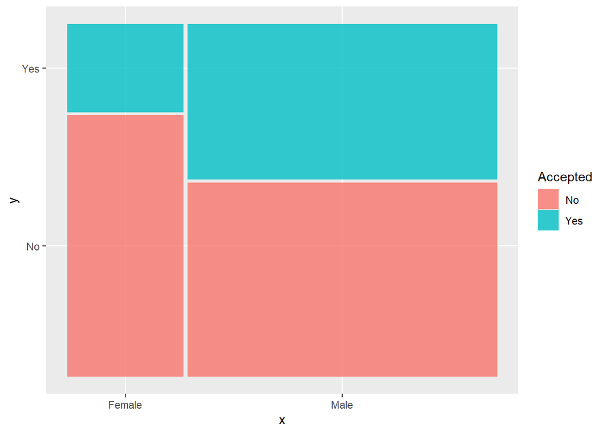

```r
#install.packages
library(ggmosaic)
ggplot(data=no.program)+
  geom_mosaic(aes(x=product(Accepted,Sex),fill=Accepted))
```

What’s your thoughts?

What would the mosaic plot look like if sex was not associated with acceptance?

What other variables might help us predict whether or not someone would be accepted?

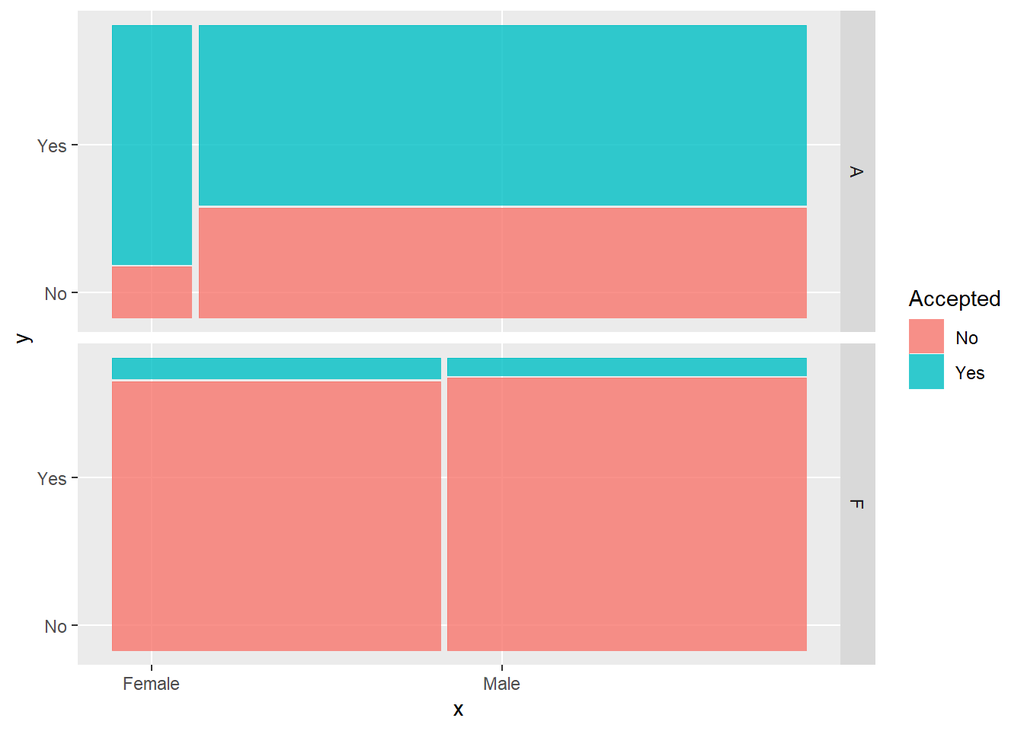

```r
ggplot(data=berkley.data)+
  geom_mosaic(aes(x=product(Accepted,Sex),fill=Accepted))+
  facet_grid(Program~.)
```

What are your thoughts looking at this plot?

How can it be that females have higher acceptance rates than males in Program A AND in Program F but when we combine the two, the overall acceptance rate is noticeably smaller for females?

What else could contribute to an admissions decision other than sex and program?

Six Steps of a statistical investigation

Did we do this with the Berkley Data? What would you tell the college administrators?

Let’s brainstorm how to write a statistical model for the Berkley data